# Fifty States Project

3/23/2022

## Data Source and Procedures

### Open Source Software & Publicly Available Data

- GSOM (Global Summary of Monthly Data)
- Analysis and Graphics R/Rstudio
- Selected Station with longest records and fewest missing data
- Select month had strongest trend
- Evaluate Monthly Temp. Max and Min for trends

## Weather Station Selected

- Station ID WINNEMUCCA AIRPORT, NV US (ID: GHCND:USW00024128)
- Records begin: 1877
- Records end: 2022
- Not necessarily representative of the state or similar to other stations in Nevada!

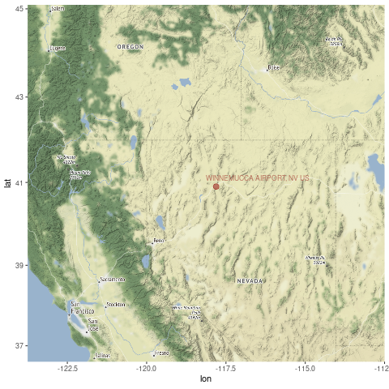

## Months with Largest Changes

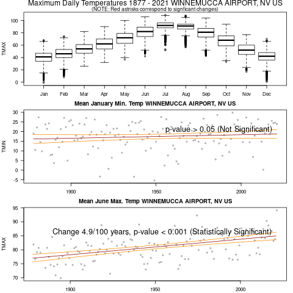

## Record Temperatures

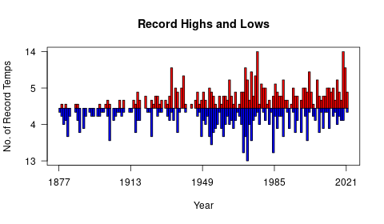

## Max. Temperature Anomaly Trend

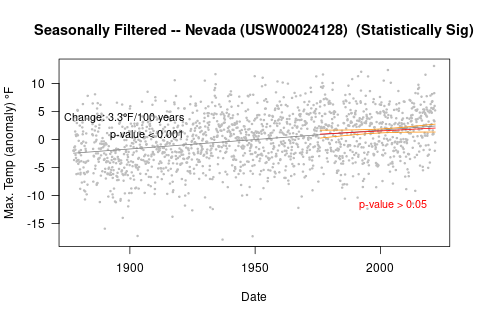

## Impacts

- Nevada’s climate is changing.
- The state has warmed about two degrees (F) in the last century.
- Throughout the southwestern United States, heat waves are becoming more common, and snow is melting earlier in spring.
- In the coming decades, the changing climate is likely to decrease the flow of water in the Colorado and other rivers in Nevada, increase the frequency and intensity of wildfires, and decrease the productivity of ranches and farms.

[EPA Snapshot](https://19january2017snapshot.epa.gov/sites/production/files/2016-09/documents/climate-change-nv.pdf)

## State Adaptation / Mitigation Plans

- Nevada has not developed a statewide adaptation plan. Other resources from the Adaptation Clearinghouse, which have been developed by the state and localities to help communities prepare for climate change, are highlighted below.
- Nevada Wildlife Action Plan Biodiversity and ecosystems, Fish and fisheries, Land management and conservation, Wildlife March 1, 2013
- All-In Clark County: Clark County’s Sustainability and Climate Action Plan February 16, 2021

[Source: Georgetown Climate Center] (https://www.georgetownclimate.org/adaptation/state-information/nevada/overview.html)

## Next Steps

- Put ideas in comments how what other can do to support state efforts
- Be kind: Responding to climate change includes a complex array of ethical issues.
- “Be curious”, Ted Lasso.